# A local RAG chatbot

local platform for LLMs

Mick McQuaid

mcq@utexas.edu

University of Texas at Austin

21 Mar 2026

# Week TEN

# Agenda

- Presentation: Jiefang
- News
- Review whatiknow
- Today’s plan
- Ollama
- Qwen 3.5
- Local RAG chatbot
- Work time

# Presentation

# News

## AI in the Courts

[figure not shown]

## AI in the Courts

- The above captioned reference manual, National Academies of Sciences, Engineering, and Medicine and Federal Judicial Center (2025), is meant for judges
- The US government keeps a copy of it online (minus the chapter about climate science!)
- The value for this class is the very detailed AI chapter, which includes an overview of AI for the layperson, as well discussions of ethics, especially bias
- It is written by legal scholars, not computer scientists
- You can download a copy from the US government’s website (without the chapter on climate science) or the full copy from the [National Academies of Sciences, Engineering, and Medicine website](https://nap.nationalacademies.org/26919)

## Autonomous Learning

- We looked at lmlm (pronounced “lam-lam”), a way to compartmentalize knowledge so that an LLM doesn’t grow stale long after training
- A completely different approach is outlined in a new paper, Dupoux, LeCun, and Malik (2026), which proposes that LLMs should keep learning after training
- The architecture is just a proposal at this stage, but it could be influential
- Let’s look at the architecture, but first …

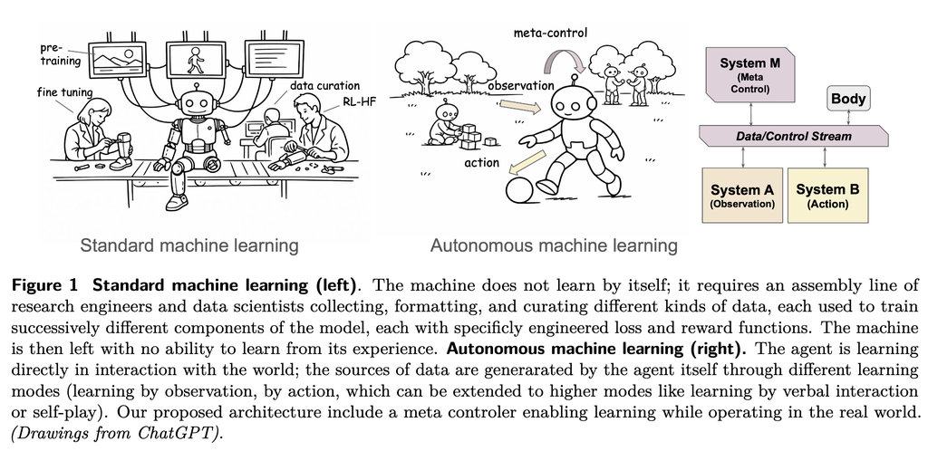

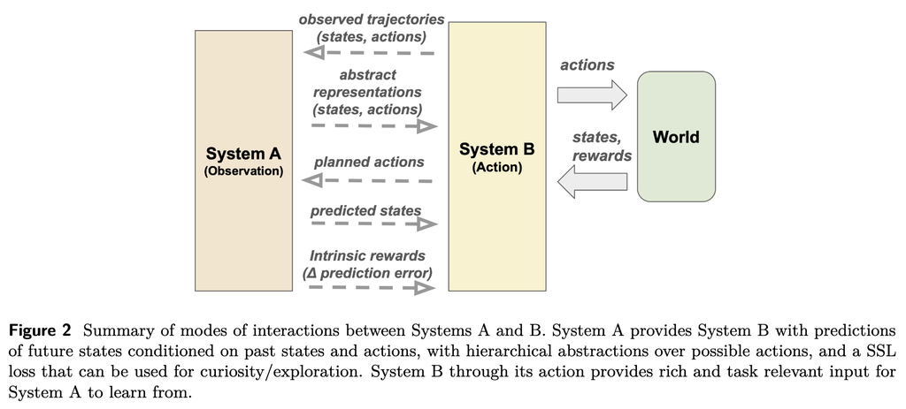

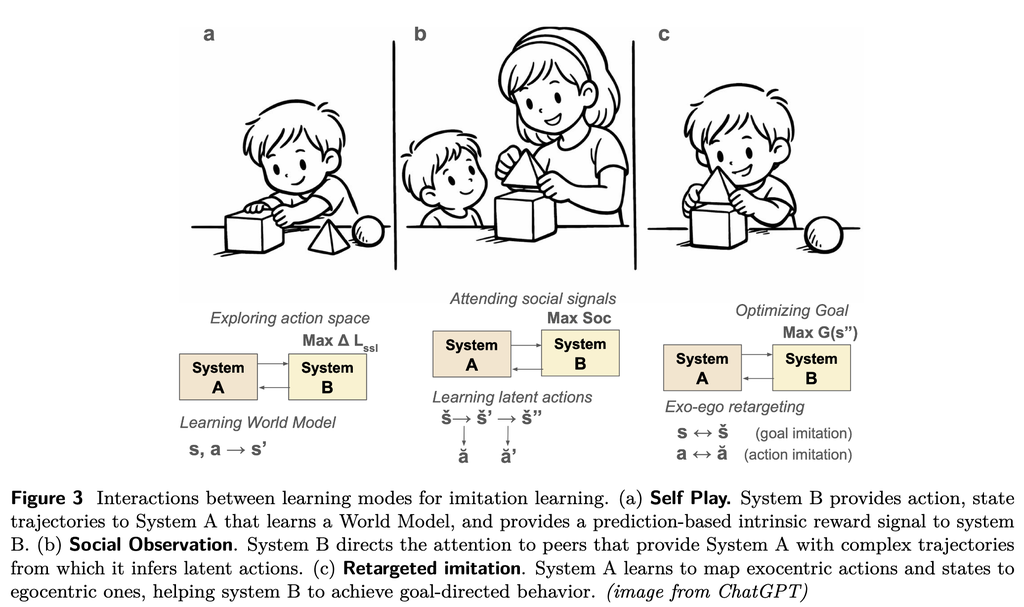

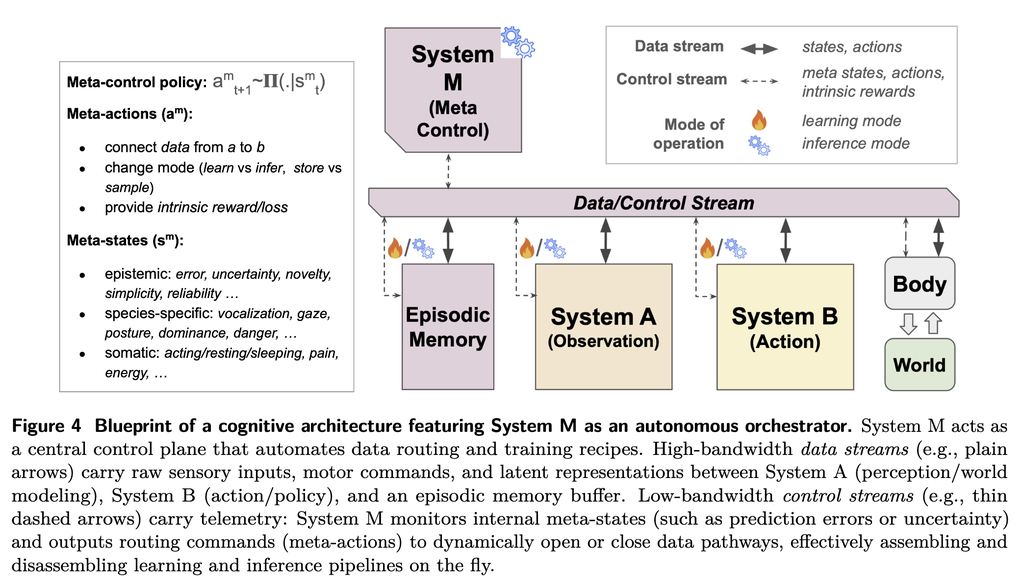

## AI and diagrams

Last semester in week 10, we looked at AI diagramming as follows:

*It’s worth looking at the AI and diagrams article that was posted to Hacker News, along with the HN comments, which are more generally focused on prompting techniques. The article discusses the use of AI to generate diagrams, and concludes that it’s good for simple diagrams and brainstorming, but struggles with complex diagrams and diagrams of systems that require insights into the system that are not well-documented.*

https://news.ycombinator.com/item?id=43398434

It may be worthwhile to see how things have changed (or not).

## TikZilla

- Instead of drawing diagrams interactively, you can write programs to draw diagrams with TikZ. Since genAI is good at writing code, writing TikZ code might be a good approach.
- A recent paper, Greisinger and Eger (2026), describes a tool called TikZilla, which is a tool for generating TikZ code from natural language descriptions and correcting faulty TikZ code.

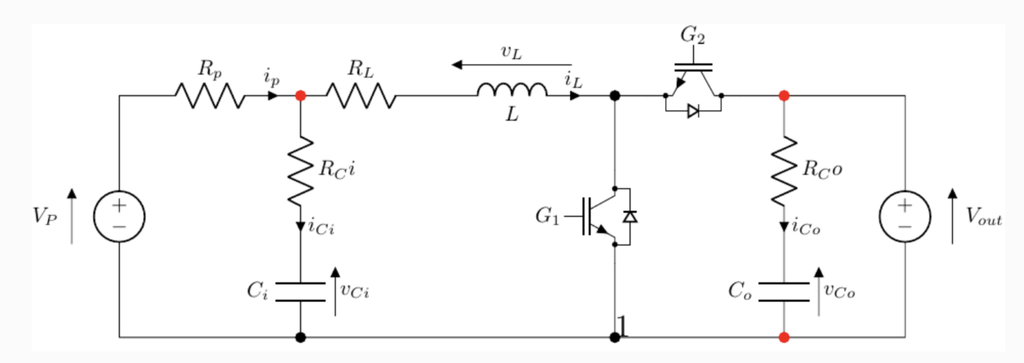

## The code that was supposed to produce it

```latex
Published as a conference paper at ICLR 2026
LLM-based TikZ Debugging
Original TikZ Code:
\documentclass[tikz]{standalone}
\usepackage[utf8]{inputenc}
\usepackage{circuitikz}
\usepackage{float}
\usepackage{calc}
\begin{document}
\begin{circuitikz}[american, straight voltages]
\draw (-1,0)
to [american voltage source, v=$V_P$, invert, voltage shift=1] (-1,4)
to [R, R=$R_p$, i^>=$i_p$] (2,4)
to [R=$R_L$] (4,4)
to [L, l_=$L$, v^<=$v_L$, i=$i_L$, voltage shift=1.5] (7,4)
to [Tnigbt,bodydiode] (10,4)
to [short] (12,4)
to [american voltage source, v^<=$V_{out}$, voltage shift=1] (12,0)
to [short] (-1,0)
(2.0,4) to [R=$R_Ci$, i=$i_{Ci}$] (2.0,1.5)
to [C, l_=$C_i$, v^<=$v_{Ci}$] (2.0,0)
(7.2,4) to [Tnigbt,bodydiode, invert] (7.2,0)
(10.0,4) to [R=$R_Co$, i=$i_{Co}$] (10.0,1.5)
to [C, l_=$C_o$, v^<=$v_{Co}$] (10.0,0)
(8.5,5) node[align=center]{$G_2$}
(6.1,2) node[align=center]{$G_1$}
(7.2,0) node[circ, scale=1.5]{$1$}
(7.2,4) node[circ, scale=1.5]
(2,0) node[circ, scale=1.5]
(2,4) node[circ, color=red, scale=1.5]
(10,4) node[circ, color=red, scale=1.5]
(10,0) node[circ, color=red, scale=1.5]
;
\end{circuitikz}
\end{document}
```

## TikZilla fixed that code in one pass

- TikZ is used within LaTeX
- Several other packages for drawing from code exist
- Mermaid, GraphViz, PlantUML, and others can be augmented by LLMs in general or,etter still, by specialized tools like TikZilla
- If you have to draw complicated diagrams, it pays to look for one of these tools

## A TikZ example of mine

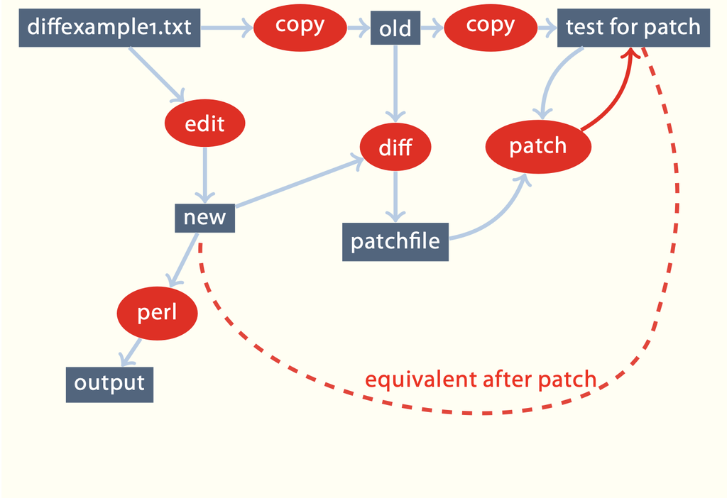